# 重賞レース予測レポート【レース終了】

作成日時: 2026/05/17 16:18:55

☞ [マニュアル(pdf)](https://ryutoro-galois.github.io/keiba-predictor/manual/manual.pdf)

☞ 過去6年の同一レース結果: [2025年](https://ryutoro-galois.github.io/keiba-predictor/report/PredResult_2025y_raceDate_20250517_20250518.html), [2024年](https://ryutoro-galois.github.io/keiba-predictor/report/PredResult_2024y_raceDate_20240511_20240512.html), [2023年](https://ryutoro-galois.github.io/keiba-predictor/report/PredResult_2023y_raceDate_20230513_20230514.html), [2022年](https://ryutoro-galois.github.io/keiba-predictor/report/PredResult_2022y_raceDate_20220514_20220515.html), [2021年](https://ryutoro-galois.github.io/keiba-predictor/report/PredResult_2021y_raceDate_20210515_20210516.html), [2020年](https://ryutoro-galois.github.io/keiba-predictor/report/PredResult_2020y_raceDate_20200516_20200517.html)

☞ 過去4週間の別レース結果: [1週前(5/9-10)](https://ryutoro-galois.github.io/keiba-predictor/report/PredResult_2026y_raceDate_20260509_20260510.html), [2週前(5/2-3)](https://ryutoro-galois.github.io/keiba-predictor/report/PredResult_2026y_raceDate_20260502_20260503.html), [3週前(4/25-26)](https://ryutoro-galois.github.io/keiba-predictor/report/PredResult_2026y_raceDate_20260425_20260426.html), [4週前(4/18-19)](https://ryutoro-galois.github.io/keiba-predictor/report/PredResult_2026y_raceDate_20260418_20260419.html)

☞ netkeiba: [京都ハイジャンプ(JGⅡ)](https://race.netkeiba.com/race/result.html?race_id=202608030708&rf=race_submenu), [新潟大賞典(GⅢ)](https://race.netkeiba.com/race/result.html?race_id=202604010511&rf=race_submenu), [ヴィクトリアマイル(GⅠ)](https://race.netkeiba.com/race/result.html?race_id=202605020811&rf=race_submenu)

☞ レース結果(csv): [5/16-17](https://ryutoro-galois.github.io/keiba-predictor/csv/race_result_20260516_20260517.csv)

## 【レース結果(1)】人気と着順の関係

### 【京都ハイジャンプ(2026/05/16(土))】

【京都ハイジャンプ(J.GⅡ)】  
2026/05/16(土), 08_京都, 障芝3930m

[interactive chart not shown]

### 【新潟大賞典(2026/05/16(土))】

【新潟大賞典(GⅢ)】  
2026/05/16(土), 04_新潟, 芝左外2000m

[interactive chart not shown]

### 【ヴィクトリアマイル(2026/05/17(日))】

【ヴィクトリアマイル(GⅠ)】  
2026/05/17(日), 05_東京, 芝左1600m

[interactive chart not shown]

## 【レース結果(2)】コーナー通過順位

### 【京都ハイジャンプ(2026/05/16(土))】

【京都ハイジャンプ(J.GⅡ)】  
2026/05/16(土), 08_京都, 障芝3930m

[interactive chart not shown]

### 【新潟大賞典(2026/05/16(土))】

【新潟大賞典(GⅢ)】  
2026/05/16(土), 04_新潟, 芝左外2000m

[interactive chart not shown]

### 【ヴィクトリアマイル(2026/05/17(日))】

【ヴィクトリアマイル(GⅠ)】  
2026/05/17(日), 05_東京, 芝左1600m

[interactive chart not shown]

## 0. 推し馬予測 (AI予測)

### 【京都ハイジャンプ(J.GⅡ) 2026/05/16(土)】

- 本命(◎): 1-3着内確率(勝負強さ)が1位の馬
- 対抗(◯): 1-3着内確率が2-N位(20%程度以上)の中で予測タイムが最も速い馬
- 3番手(▲): 1-3着内確率が2-N位(20%程度以上)のでダークホース確率が最も高い馬
- 穴: ダークホース確率が上位1-M位(40%程度以上)の中で1-3着内確率が最も高い馬

| 推し馬 | 枠番 | 馬番 | 人気 | オッズ | 馬名 | 騎手 | 調教師 | 予測タイム(sec) | 1_順位 | 1-3着内確率(%) | 2_順位 | ﾀﾞｰｸﾎｰｽ確率(%) | 3_順位 |
| --- | --- | --- | --- | --- | --- | --- | --- | --- | --- | --- | --- | --- | --- |
| 本命(◎) | 5 | 5 | 2 | 3.7 | シホノスペランツァ | 高田潤 | 寺島良 | 287.8 | 3 | 20.6 | 1 | 1.3 | 4 |
| 対抗(◯) | 4 | 4 | 1 | 1.7 | ネビーイーム | 小牧加矢太 | 中竹和也 | 261.6 | 1 | 15.3 | 2 | 0.7 | 6 |
| 3番手(▲) | 2 | 2 | 6 | 42.3 | ヴラディア | 上野翔 | 松尾卓哉 | 284.0 | 2 | 5.5 | 4 | 36.7 | 1 |
| 穴 | 1 | 1 | 3 | 6.5 | ダノンロッキー | 五十嵐雄祐 | 萩原清 | 288.1 | 4 | 5.9 | 3 | 0.8 | 5 |

### 【新潟大賞典(GⅢ) 2026/05/16(土)】

- 本命(◎): 1-3着内確率(勝負強さ)が1位の馬
- 対抗(◯): 1-3着内確率が2-N位(20%程度以上)の中で予測タイムが最も速い馬
- 3番手(▲): 1-3着内確率が2-N位(20%程度以上)のでダークホース確率が最も高い馬
- 穴: ダークホース確率が上位1-M位(40%程度以上)の中で1-3着内確率が最も高い馬

| 推し馬 | 枠番 | 馬番 | 人気 | オッズ | 馬名 | 騎手 | 調教師 | 予測タイム(sec) | 1_順位 | 1-3着内確率(%) | 2_順位 | ﾀﾞｰｸﾎｰｽ確率(%) | 3_順位 |
| --- | --- | --- | --- | --- | --- | --- | --- | --- | --- | --- | --- | --- | --- |
| 本命(◎) | 8 | 15 | 2 | 7.0 | シュガークン | 武豊 | 清水久詞 | 127.9 | 6.0 | 27.8 | 1 | 0.5 | 15 |
| 対抗(◯) | 4 | 6 | 1 | 2.5 | ドゥラドーレス | Ｃ．ルメール | 宮田敬介 | 116.9 | 1.5 | 20.6 | 5 | 0.5 | 14 |
| 3番手(▲) | 5 | 8 | 6 | 12.2 | ヤマニンブークリエ | 横山典弘 | 松永幹夫 | 128.5 | 11.0 | 21.8 | 3 | 1.4 | 10 |
| 穴 | 3 | 5 | 14 | 159.9 | グランドカリナン | 小林美駒 | 田島俊明 | 127.9 | 7.0 | 9.1 | 9 | 53.9 | 1 |

### 【ヴィクトリアマイル(GⅠ) 2026/05/17(日)】

- 本命(◎): 1-3着内確率(勝負強さ)が1位の馬
- 対抗(◯): 1-3着内確率が2-N位(20%程度以上)の中で予測タイムが最も速い馬
- 3番手(▲): 1-3着内確率が2-N位(20%程度以上)のでダークホース確率が最も高い馬
- 穴: ダークホース確率が上位1-M位(40%程度以上)の中で1-3着内確率が最も高い馬

| 推し馬 | 枠番 | 馬番 | 人気 | オッズ | 馬名 | 騎手 | 調教師 | 予測タイム(sec) | 1_順位 | 1-3着内確率(%) | 2_順位 | ﾀﾞｰｸﾎｰｽ確率(%) | 3_順位 |
| --- | --- | --- | --- | --- | --- | --- | --- | --- | --- | --- | --- | --- | --- |
| 本命(◎) | 6 | 11 | 11 | 34.0 | ボンドガール | 丹内祐次 | 手塚貴久 | 94.0 | 7.0 | 65.7 | 1 | 51.2 | 7 |
| 対抗(◯) | 4 | 8 | 2 | 5.9 | カムニャック | 川田将雅 | 友道康夫 | 90.5 | 3.5 | 25.1 | 4 | 1.8 | 16 |
| 3番手(▲) | 7 | 15 | 12 | 35.6 | アイサンサン | 幸英明 | 橋田宜長 | 96.4 | 8.0 | 39.1 | 2 | 55.1 | 6 |
| 穴 | 2 | 3 | 15 | 77.6 | マピュース | Ｆ．ゴンサルベス | 和田勇介 | 90.5 | 3.5 | 15.7 | 8 | 71.6 | 3 |

## 1. 予測チャート (タイム/勝負強さ)

### 【京都ハイジャンプ(J.GⅡ)】

2026/05/16(土), 08_京都, 障芝3930m

[interactive chart not shown]

### 【新潟大賞典(GⅢ)】

2026/05/16(土), 04_新潟, 芝左外2000m

[interactive chart not shown]

### 【ヴィクトリアマイル(GⅠ)】

2026/05/17(日), 05_東京, 芝左1600m

[interactive chart not shown]

## 2. オッズモニタリング (毎時)

### 【京都ハイジャンプ】

[interactive chart not shown]

### 【新潟大賞典】

[interactive chart not shown]

### 【ヴィクトリアマイル】

[interactive chart not shown]

## 3. 出馬表

### 【京都ハイジャンプ 2026/05/16(土) 】

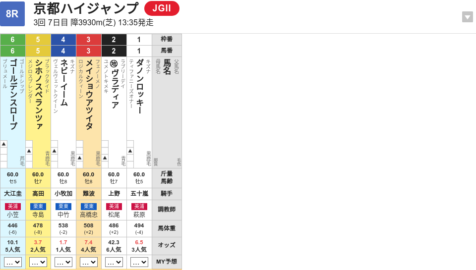

### 【新潟大賞典 2026/05/16(土) 】

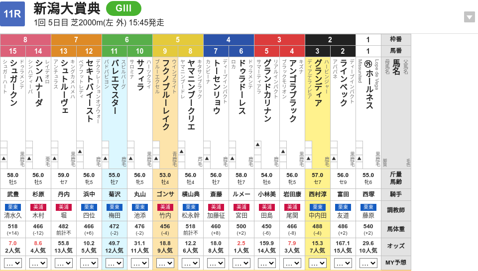

### 【ヴィクトリアマイル 2026/05/17(日) 】

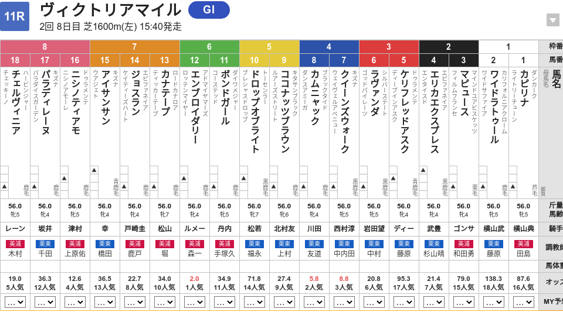

## 4. 単勝予測結果

### 【京都ハイジャンプ(J.GⅡ) 2026/05/16(土)】

| 枠番 | 馬番 | 人気 | オッズ | 馬名 | 騎手 | 調教師 | 予測タイム(sec) | 1_順位 | 1-3着内確率(%) | 2_順位 | ﾀﾞｰｸﾎｰｽ確率(%) | 3_順位 |
| --- | --- | --- | --- | --- | --- | --- | --- | --- | --- | --- | --- | --- |
| 1 | 1 | 3 | 6.5 | ダノンロッキー | 五十嵐雄祐 | 萩原清 | 288.1 | 4 | 5.9 | 3 | 0.8 | 5 |
| 2 | 2 | 6 | 42.3 | ヴラディア | 上野翔 | 松尾卓哉 | 284.0 | 2 | 5.5 | 4 | 36.7 | 1 |
| 3 | 3 | 4 | 7.4 | メイショウアツイタ | 難波剛健 | 高橋義忠 | 288.2 | 6 | 3.0 | 6 | 12.0 | 2 |
| 4 | 4 | 1 | 1.7 | ネビーイーム | 小牧加矢太 | 中竹和也 | 261.6 | 1 | 15.3 | 2 | 0.7 | 6 |
| 5 | 5 | 2 | 3.7 | シホノスペランツァ | 高田潤 | 寺島良 | 287.8 | 3 | 20.6 | 1 | 1.3 | 4 |
| 6 | 6 | 5 | 10.1 | ゴールデンスロープ | 大江原圭 | 小笠倫弘 | 288.1 | 5 | 3.3 | 5 | 11.7 | 3 |

### 【新潟大賞典(GⅢ) 2026/05/16(土)】

| 枠番 | 馬番 | 人気 | オッズ | 馬名 | 騎手 | 調教師 | 予測タイム(sec) | 1_順位 | 1-3着内確率(%) | 2_順位 | ﾀﾞｰｸﾎｰｽ確率(%) | 3_順位 |
| --- | --- | --- | --- | --- | --- | --- | --- | --- | --- | --- | --- | --- |
| 1 | 1 | 10 | 29.6 | ホールネス | 西塚洸二 | 藤原英昭 | 128.5 | 12.0 | 4.1 | 14 | 52.6 | 2 |
| 2 | 2 | 15 | 167.1 | ラインベック | 富田暁 | 友道康夫 | 116.9 | 1.5 | 6.5 | 12 | 20.2 | 7 |
| 2 | 3 | 7 | 15.3 | グランディア | 西村淳也 | 中内田充正 | 121.7 | 3.0 | 11.5 | 6 | 1.4 | 8 |
| 3 | 4 | 3 | 7.9 | アンゴラブラック | 岩田康誠 | 尾関知人 | 128.1 | 9.0 | 27.7 | 2 | 0.5 | 13 |
| 3 | 5 | 14 | 159.9 | グランドカリナン | 小林美駒 | 田島俊明 | 127.9 | 7.0 | 9.1 | 9 | 53.9 | 1 |
| 4 | 6 | 1 | 2.5 | ドゥラドーレス | Ｃ．ルメール | 宮田敬介 | 116.9 | 1.5 | 20.6 | 5 | 0.5 | 14 |
| 4 | 7 | 8 | 18.0 | トーセンリョウ | 斎藤新 | 加藤征弘 | 128.7 | 13.0 | 6.6 | 11 | 1.4 | 9 |
| 5 | 8 | 6 | 12.2 | ヤマニンブークリエ | 横山典弘 | 松永幹夫 | 128.5 | 11.0 | 21.8 | 3 | 1.4 | 10 |
| 5 | 9 | 9 | 18.8 | フクノブルーレイク | Ｆ．ゴンサルベス | 竹内正洋 | 128.8 | 15.0 | 10.4 | 8 | 34.3 | 5 |
| 6 | 10 | 11 | 31.1 | サフィラ | 丸山元気 | 池添学 | 124.0 | 4.0 | 6.0 | 13 | 40.4 | 4 |

[output cut: 5 more lines]

### 【ヴィクトリアマイル(GⅠ) 2026/05/17(日)】

| 枠番 | 馬番 | 人気 | オッズ | 馬名 | 騎手 | 調教師 | 予測タイム(sec) | 1_順位 | 1-3着内確率(%) | 2_順位 | ﾀﾞｰｸﾎｰｽ確率(%) | 3_順位 |
| --- | --- | --- | --- | --- | --- | --- | --- | --- | --- | --- | --- | --- |
| 1 | 1 | 16 | 85.6 | カピリナ | 横山典弘 | 田島俊明 | 90.5 | 3.5 | 15.2 | 9 | 72.5 | 2 |
| 1 | 2 | 18 | 137.0 | ワイドラトゥール | 横山武史 | 藤原英昭 | 90.5 | 3.5 | 15.0 | 10 | 68.8 | 4 |
| 2 | 3 | 15 | 77.6 | マピュース | Ｆ．ゴンサルベス | 和田勇介 | 90.5 | 3.5 | 15.7 | 8 | 71.6 | 3 |
| 2 | 4 | 7 | 21.4 | エリカエクスプレス | 武豊 | 杉山晴紀 | 97.3 | 10.0 | 14.0 | 12 | 2.4 | 11 |
| 3 | 5 | 17 | 94.2 | ケリフレッドアスク | Ｍ．ディー | 藤原英昭 | 90.5 | 3.5 | 14.5 | 11 | 73.5 | 1 |
| 3 | 6 | 6 | 20.9 | ラヴァンダ | 岩田望来 | 中村直也 | 104.1 | 18.0 | 11.9 | 15 | 1.7 | 18 |
| 4 | 7 | 3 | 8.9 | クイーンズウォーク | 西村淳也 | 中内田充正 | 99.4 | 13.0 | 22.1 | 5 | 1.8 | 17 |
| 4 | 8 | 2 | 5.9 | カムニャック | 川田将雅 | 友道康夫 | 90.5 | 3.5 | 25.1 | 4 | 1.8 | 16 |
| 5 | 9 | 9 | 27.4 | ココナッツブラウン | 北村友一 | 上村洋行 | 100.8 | 15.0 | 10.7 | 17 | 1.9 | 15 |
| 5 | 10 | 14 | 70.6 | ドロップオブライト | 松若風馬 | 福永祐一 | 102.7 | 16.0 | 6.0 | 18 | 15.1 | 8 |

[output cut: 8 more lines]

## 5. 人気と着順の乖離率推移

### 【京都ハイジャンプ_1999y_2019y】

[interactive chart not shown]

### 【新潟大賞典_1990y_2019y】

[interactive chart not shown]

### 【ヴィクトリアマイル_2006y_2019y】

[interactive chart not shown]

### 【京都ハイジャンプ_1999y_2019y】

| No | 開催年 | 不整合率(%) | 頭数 | 人気別着順(1-3位) | 人気別着順(全体) |
| --- | --- | --- | --- | --- | --- |
| 21 | 2019 | 42.0 | 8頭 | 8-4-5 | 8\|4\|5\|1\|2\|10\|9\|3 |
| 20 | 2018 | 25.5 | 8頭 | 2-1-4 | 2\|1\|4\|3\|6\|8\|5\|7 |
| 19 | 2017 | 16.5 | 10頭 | 1-6-3 | 1\|6\|3\|7\|10\|4\|8\|5\|9\|11 |
| 18 | 2016 | 26.8 | 13頭 | 1-3-5 | 1\|3\|5\|6\|2\|10\|8\|11\|12\|4\|9\|7\|13 |
| 17 | 2015 | 53.8 | 12頭 | 3-6-2 | 3\|6\|2\|1\|9\|8\|14\|4\|13\|10\|7\|12 |
| 16 | 2014 | 53.0 | 8頭 | 6-3-8 | 6\|3\|8\|7\|5\|2\|4\|9 |
| 15 | 2013 | 32.0 | 11頭 | 1-9-7 | 1\|9\|7\|4\|2\|10\|11\|8\|6\|3\|13 |
| 14 | 2012 | 51.9 | 12頭 | 4-2-3 | 4\|2\|3\|5\|9\|8\|1\|7\|10\|12\|6\|11 |
| 13 | 2011 | 30.1 | 13頭 | 3-1-7 | 3\|1\|7\|12\|11\|13\|9\|4\|6\|8\|14\|5\|10 |
| 12 | 2010 | 63.8 | 13頭 | 5-11-3 | 5\|11\|3\|2\|7\|6\|1\|8\|10\|12\|13\|9\|14 |

[output cut: 11 more lines]

### 【新潟大賞典_1990y_2019y】

| No | 開催年 | 不整合率(%) | 頭数 | 人気別着順(1-3位) | 人気別着順(全体) |
| --- | --- | --- | --- | --- | --- |
| 30 | 2019 | 37.7 | 16頭 | 7-3-1 | 7\|3\|1\|2\|9\|8\|10\|14\|4\|13\|12\|5\|16\|15\|11\|6 |
| 29 | 2018 | 29.3 | 16頭 | 5-9-11 | 5\|9\|11\|1\|8\|2\|15\|4\|13\|16\|3\|6\|10\|12\|7\|14 |
| 28 | 2017 | 47.4 | 16頭 | 3-11-1 | 3\|11\|1\|4\|10\|7\|14\|15\|9\|8\|12\|16\|5\|6\|2\|13 |
| 27 | 2016 | 44.1 | 16頭 | 10-1-8 | 10\|1\|8\|5\|9\|13\|11\|12\|6\|7\|3\|2\|4\|16\|15\|14 |
| 26 | 2015 | 64.7 | 16頭 | 5-13-6 | 5\|13\|6\|14\|3\|10\|4\|12\|11\|7\|9\|8\|1\|16\|15\|2 |
| 25 | 2014 | 45.7 | 16頭 | 3-2-1 | 3\|2\|1\|7\|13\|5\|4\|11\|16\|15\|9\|14\|10\|8\|6\|12 |
| 24 | 2013 | 58.3 | 16頭 | 6-3-4 | 6\|3\|4\|2\|1\|10\|13\|9\|8\|5\|7\|16\|15\|11\|12\|14 |
| 23 | 2012 | 31.1 | 15頭 | 5-11-9 | 5\|11\|9\|1\|13\|7\|8\|14\|2\|10\|3\|6\|4\|12\|15 |
| 22 | 2011 | 40.4 | 14頭 | 2-10-4 | 2\|10\|4\|8\|7\|1\|11\|9\|15\|13\|12\|3\|6\|5 |
| 21 | 2010 | 42.7 | 16頭 | 2-3-6 | 2\|3\|6\|7\|9\|8\|5\|1\|16\|4\|12\|14\|13\|10\|11\|15 |

[output cut: 20 more lines]

### 【ヴィクトリアマイル_2006y_2019y】

| No | 開催年 | 不整合率(%) | 頭数 | 人気別着順(1-3位) | 人気別着順(全体) |
| --- | --- | --- | --- | --- | --- |
| 14 | 2019 | 36.1 | 18頭 | 5-4-11 | 5\|4\|11\|1\|2\|17\|15\|6\|8\|13\|3\|10\|14\|12\|9\|16\|18\|7 |
| 13 | 2018 | 34.7 | 18頭 | 8-1-7 | 8\|1\|7\|3\|4\|6\|5\|2\|14\|9\|15\|11\|12\|10\|17\|13\|16\|18 |
| 12 | 2017 | 46.7 | 17頭 | 6-11-7 | 6\|11\|7\|4\|9\|5\|1\|12\|8\|2\|3\|13\|10\|17\|16\|15\|14 |
| 11 | 2016 | 12.2 | 18頭 | 7-1-2 | 7\|1\|2\|3\|4\|6\|15\|5\|12\|8\|10\|17\|13\|18\|14\|11\|16\|9 |
| 10 | 2015 | 48.6 | 18頭 | 5-12-18 | 5\|12\|18\|3\|4\|1\|2\|7\|16\|6\|15\|9\|11\|14\|17\|10\|8\|13 |
| 9 | 2014 | 54.6 | 18頭 | 11-3-6 | 11\|3\|6\|2\|13\|14\|4\|1\|12\|7\|15\|16\|10\|8\|9\|5\|17\|18 |
| 8 | 2013 | 31.9 | 17頭 | 1-12-5 | 1\|12\|5\|4\|7\|2\|18\|11\|15\|9\|6\|10\|8\|3\|17\|13\|14 |
| 7 | 2012 | 56.1 | 18頭 | 4-7-3 | 4\|7\|3\|11\|1\|10\|9\|18\|8\|16\|13\|17\|15\|14\|5\|2\|12\|6 |
| 6 | 2011 | 25.7 | 17頭 | 2-1-3 | 2\|1\|3\|14\|9\|12\|4\|8\|15\|17\|13\|11\|6\|10\|7\|16\|5 |
| 5 | 2010 | 24.3 | 18頭 | 1-8-11 | 1\|8\|11\|2\|4\|7\|13\|9\|5\|6\|15\|10\|3\|14\|12\|18\|17\|16 |

[output cut: 4 more lines]

## 6. 1-3番人気馬の着順分類予測

### 【京都ハイジャンプ】

| 分類 | 凡例 | 発生確率(%) | 当該レース | 当該レースランク | 直近1年間 |
| --- | --- | --- | --- | --- | --- |
| 4: 1,2番人気のみ (4_pop12) | 1 \| 2 \| * | 17.5 | 1.18 | 1.18 | 0.00 |
| 8: 1,2,3番人気すべて着外 (8_darkhorse) | * \| * \| * | 17.5 | 0.39 | 0.39 | 0.26 |
| 1: 1番人気のみ (1_pop1) | 1 \| * \| * | 17.3 | 2.34 | 2.34 | 0.00 |
| 5: 1,3番人気のみ (5_pop13) | 1 \| 3 \| * | 13.5 | 1.22 | 1.22 | 0.41 |
| 2: 2番人気のみ (2_pop2) | 2 \| * \| * | 9.6 | 0.00 | 0.00 | 0.00 |
| 3: 3番人気のみ (3_pop3) | 3 \| * \| * | 8.7 | 2.35 | 2.35 | 0.00 |
| 6: 2,3番人気のみ (6_pop23) | 2 \| 3 \| * | 8.6 | 0.77 | 0.77 | 0.00 |
| 7: 1,2,3番人気すべて着内 (7_pop123) | 1 \| 2 \| 3 | 7.3 | 0.99 | 0.99 | 0.00 |

### 【新潟大賞典】

| 分類 | 凡例 | 発生確率(%) | 当該レース | 当該レースランク | 直近1年間 |
| --- | --- | --- | --- | --- | --- |
| 5: 1,3番人気のみ (5_pop13) | 1 \| 3 \| * | 17.7 | 0.64 | 0.64 | 0.53 |
| 4: 1,2番人気のみ (4_pop12) | 1 \| 2 \| * | 17.4 | 2.10 | 2.10 | 0.00 |
| 1: 1番人気のみ (1_pop1) | 1 \| * \| * | 17.3 | 1.24 | 1.24 | 0.00 |
| 8: 1,2,3番人気すべて着外 (8_darkhorse) | * \| * \| * | 13.1 | 0.68 | 0.68 | 0.20 |
| 2: 2番人気のみ (2_pop2) | 2 \| * \| * | 9.6 | 0.69 | 0.69 | 0.00 |
| 6: 2,3番人気のみ (6_pop23) | 2 \| 3 \| * | 9.6 | 3.43 | 3.43 | 0.00 |
| 3: 3番人気のみ (3_pop3) | 3 \| * \| * | 8.5 | 1.02 | 1.02 | 0.00 |
| 7: 1,2,3番人気すべて着内 (7_pop123) | 1 \| 2 \| 3 | 6.8 | 1.21 | 1.21 | 0.00 |

### 【ヴィクトリアマイル】

| 分類 | 凡例 | 発生確率(%) | 当該レース | 当該レースランク | 直近1年間 |
| --- | --- | --- | --- | --- | --- |
| 4: 1,2番人気のみ (4_pop12) | 1 \| 2 \| * | 17.5 | 3.50 | 3.50 | 0.00 |
| 8: 1,2,3番人気すべて着外 (8_darkhorse) | * \| * \| * | 17.5 | 0.35 | 0.35 | 0.17 |
| 1: 1番人気のみ (1_pop1) | 1 \| * \| * | 17.3 | 0.69 | 0.69 | 0.00 |
| 5: 1,3番人気のみ (5_pop13) | 1 \| 3 \| * | 13.5 | 0.00 | 0.00 | 0.00 |
| 2: 2番人気のみ (2_pop2) | 2 \| * \| * | 9.6 | 0.00 | 0.00 | 0.00 |
| 3: 3番人気のみ (3_pop3) | 3 \| * \| * | 8.7 | 0.87 | 0.87 | 0.00 |
| 6: 2,3番人気のみ (6_pop23) | 2 \| 3 \| * | 8.6 | 1.72 | 1.72 | 0.00 |
| 7: 1,2,3番人気すべて着内 (7_pop123) | 1 \| 2 \| 3 | 7.3 | 1.46 | 1.46 | 0.00 |

## 7. 3連複予測結果

### 【京都ハイジャンプ(J.GⅡ) 2026/05/16(土)】

| 分類 | 馬番 | 枠番 | 人気 | 平均予測タイム(sec) | 1-3着内確率(%) | ﾀﾞｰｸﾎｰｽ確率(%) | 馬名 | 騎手 | 調教師 |
| --- | --- | --- | --- | --- | --- | --- | --- | --- | --- |
| 7: 1,2,3番人気すべて着内 (7_pop123) | 4-5-1 | 4-5-1 | 1-2-3 | 279.17 | 0.19 | 0.00 | ネビーイーム \| シホノスペランツァ \| ダノンロッキー | 小牧加矢太 \| 高田潤 \| 五十嵐雄祐 | 中竹和也 \| 寺島良 \| 萩原清 |
| 4: 1,2番人気のみ (4_pop12) | 4-5-2 | 4-5-2 | 1-2-6 | 277.80 | 0.17 | 0.00 | ネビーイーム \| シホノスペランツァ \| ヴラディア | 小牧加矢太 \| 高田潤 \| 上野翔 | 中竹和也 \| 寺島良 \| 松尾卓哉 |
| 4: 1,2番人気のみ (4_pop12) | 4-5-6 | 4-5-6 | 1-2-5 | 279.17 | 0.10 | 0.00 | ネビーイーム \| シホノスペランツァ \| ゴールデンスロープ | 小牧加矢太 \| 高田潤 \| 大江原圭 | 中竹和也 \| 寺島良 \| 小笠倫弘 |
| 4: 1,2番人気のみ (4_pop12) | 4-5-3 | 4-5-3 | 1-2-4 | 279.20 | 0.09 | 0.00 | ネビーイーム \| シホノスペランツァ \| メイショウアツイタ | 小牧加矢太 \| 高田潤 \| 難波剛健 | 中竹和也 \| 寺島良 \| 高橋義忠 |
| 6: 2,3番人気のみ (6_pop23) | 5-1-2 | 5-1-2 | 2-3-6 | 286.63 | 0.07 | 0.00 | シホノスペランツァ \| ダノンロッキー \| ヴラディア | 高田潤 \| 五十嵐雄祐 \| 上野翔 | 寺島良 \| 萩原清 \| 松尾卓哉 |
| 5: 1,3番人気のみ (5_pop13) | 4-1-2 | 4-1-2 | 1-3-6 | 277.90 | 0.05 | 0.00 | ネビーイーム \| ダノンロッキー \| ヴラディア | 小牧加矢太 \| 五十嵐雄祐 \| 上野翔 | 中竹和也 \| 萩原清 \| 松尾卓哉 |
| 6: 2,3番人気のみ (6_pop23) | 5-1-6 | 5-1-6 | 2-3-5 | 288.00 | 0.04 | 0.00 | シホノスペランツァ \| ダノンロッキー \| ゴールデンスロープ | 高田潤 \| 五十嵐雄祐 \| 大江原圭 | 寺島良 \| 萩原清 \| 小笠倫弘 |
| 2: 2番人気のみ (2_pop2) | 5-6-2 | 5-6-2 | 2-5-6 | 286.63 | 0.04 | 0.06 | シホノスペランツァ \| ゴールデンスロープ \| ヴラディア | 高田潤 \| 大江原圭 \| 上野翔 | 寺島良 \| 小笠倫弘 \| 松尾卓哉 |
| 6: 2,3番人気のみ (6_pop23) | 5-1-3 | 5-1-3 | 2-3-4 | 288.03 | 0.04 | 0.00 | シホノスペランツァ \| ダノンロッキー \| メイショウアツイタ | 高田潤 \| 五十嵐雄祐 \| 難波剛健 | 寺島良 \| 萩原清 \| 高橋義忠 |
| 2: 2番人気のみ (2_pop2) | 5-3-2 | 5-3-2 | 2-4-6 | 286.67 | 0.03 | 0.06 | シホノスペランツァ \| メイショウアツイタ \| ヴラディア | 高田潤 \| 難波剛健 \| 上野翔 | 寺島良 \| 高橋義忠 \| 松尾卓哉 |

[output cut: 10 more lines]

### 【新潟大賞典(GⅢ) 2026/05/16(土)】

| 分類 | 馬番 | 枠番 | 人気 | 平均予測タイム(sec) | 1-3着内確率(%) | ﾀﾞｰｸﾎｰｽ確率(%) | 馬名 | 騎手 | 調教師 |
| --- | --- | --- | --- | --- | --- | --- | --- | --- | --- |
| 6: 2,3番人気のみ (6_pop23) | 15-4-8 | 8-3-5 | 2-3-6 | 128.17 | 1.68 | 0.00 | シュガークン \| アンゴラブラック \| ヤマニンブークリエ | 武豊 \| 岩田康誠 \| 横山典弘 | 清水久詞 \| 尾関知人 \| 松永幹夫 |
| 6: 2,3番人気のみ (6_pop23) | 15-4-14 | 8-3-8 | 2-3-4 | 128.03 | 1.59 | 0.00 | シュガークン \| アンゴラブラック \| シンハナーダ | 武豊 \| 岩田康誠 \| 杉原誠人 | 清水久詞 \| 尾関知人 \| 木村哲也 |
| 7: 1,2,3番人気すべて着内 (7_pop123) | 6-15-4 | 4-8-3 | 1-2-3 | 124.30 | 1.58 | 0.00 | ドゥラドーレス \| シュガークン \| アンゴラブラック | Ｃ．ルメール \| 武豊 \| 岩田康誠 | 宮田敬介 \| 清水久詞 \| 尾関知人 |
| 2: 2番人気のみ (2_pop2) | 15-14-8 | 8-8-5 | 2-4-6 | 128.17 | 1.26 | 0.00 | シュガークン \| シンハナーダ \| ヤマニンブークリエ | 武豊 \| 杉原誠人 \| 横山典弘 | 清水久詞 \| 木村哲也 \| 松永幹夫 |
| 4: 1,2番人気のみ (4_pop12) | 6-15-8 | 4-8-5 | 1-2-6 | 124.43 | 1.25 | 0.00 | ドゥラドーレス \| シュガークン \| ヤマニンブークリエ | Ｃ．ルメール \| 武豊 \| 横山典弘 | 宮田敬介 \| 清水久詞 \| 松永幹夫 |
| 3: 3番人気のみ (3_pop3) | 4-14-8 | 3-8-5 | 3-4-6 | 128.23 | 1.25 | 0.00 | アンゴラブラック \| シンハナーダ \| ヤマニンブークリエ | 岩田康誠 \| 杉原誠人 \| 横山典弘 | 尾関知人 \| 木村哲也 \| 松永幹夫 |
| 5: 1,3番人気のみ (5_pop13) | 6-4-8 | 4-3-5 | 1-3-6 | 124.50 | 1.24 | 0.00 | ドゥラドーレス \| アンゴラブラック \| ヤマニンブークリエ | Ｃ．ルメール \| 岩田康誠 \| 横山典弘 | 宮田敬介 \| 尾関知人 \| 松永幹夫 |
| 4: 1,2番人気のみ (4_pop12) | 6-15-14 | 4-8-8 | 1-2-4 | 124.30 | 1.19 | 0.00 | ドゥラドーレス \| シュガークン \| シンハナーダ | Ｃ．ルメール \| 武豊 \| 杉原誠人 | 宮田敬介 \| 清水久詞 \| 木村哲也 |
| 5: 1,3番人気のみ (5_pop13) | 6-4-14 | 4-3-8 | 1-3-4 | 124.37 | 1.18 | 0.00 | ドゥラドーレス \| アンゴラブラック \| シンハナーダ | Ｃ．ルメール \| 岩田康誠 \| 杉原誠人 | 宮田敬介 \| 尾関知人 \| 木村哲也 |
| 1: 1番人気のみ (1_pop1) | 6-14-8 | 4-8-5 | 1-4-6 | 124.50 | 0.93 | 0.00 | ドゥラドーレス \| シンハナーダ \| ヤマニンブークリエ | Ｃ．ルメール \| 杉原誠人 \| 横山典弘 | 宮田敬介 \| 木村哲也 \| 松永幹夫 |

[output cut: 445 more lines]

### 【ヴィクトリアマイル(GⅠ) 2026/05/17(日)】

| 分類 | 馬番 | 枠番 | 人気 | 平均予測タイム(sec) | 1-3着内確率(%) | ﾀﾞｰｸﾎｰｽ確率(%) | 馬名 | 騎手 | 調教師 |
| --- | --- | --- | --- | --- | --- | --- | --- | --- | --- |
| 8: 1,2,3番人気すべて着外 (8_darkhorse) | 18-11-15 | 8-6-7 | 5-11-12 | 96.60 | 6.65 | 0.59 | チェルヴィニア \| ボンドガール \| アイサンサン | Ｄ．レーン \| 丹内祐次 \| 幸英明 | 木村哲也 \| 手塚貴久 \| 橋田宜長 |
| 2: 2番人気のみ (2_pop2) | 8-11-15 | 4-6-7 | 2-11-12 | 93.63 | 6.46 | 0.52 | カムニャック \| ボンドガール \| アイサンサン | 川田将雅 \| 丹内祐次 \| 幸英明 | 友道康夫 \| 手塚貴久 \| 橋田宜長 |
| 3: 3番人気のみ (3_pop3) | 7-11-15 | 4-6-7 | 3-11-12 | 96.60 | 5.69 | 0.51 | クイーンズウォーク \| ボンドガール \| アイサンサン | 西村淳也 \| 丹内祐次 \| 幸英明 | 中内田充正 \| 手塚貴久 \| 橋田宜長 |
| 1: 1番人気のみ (1_pop1) | 12-11-15 | 6-6-7 | 1-11-12 | 93.63 | 4.70 | 0.58 | エンブロイダリー \| ボンドガール \| アイサンサン | Ｃ．ルメール \| 丹内祐次 \| 幸英明 | 森一誠 \| 手塚貴久 \| 橋田宜長 |
| 8: 1,2,3番人気すべて着外 (8_darkhorse) | 16-11-15 | 8-6-7 | 4-11-12 | 96.93 | 4.32 | 0.62 | ニシノティアモ \| ボンドガール \| アイサンサン | 津村明秀 \| 丹内祐次 \| 幸英明 | 上原佑紀 \| 手塚貴久 \| 橋田宜長 |
| 2: 2番人気のみ (2_pop2) | 8-18-11 | 4-8-6 | 2-5-11 | 94.63 | 4.27 | 0.02 | カムニャック \| チェルヴィニア \| ボンドガール | 川田将雅 \| Ｄ．レーン \| 丹内祐次 | 友道康夫 \| 木村哲也 \| 手塚貴久 |
| 8: 1,2,3番人気すべて着外 (8_darkhorse) | 11-15-3 | 6-7-2 | 11-12-15 | 93.63 | 4.03 | 20.21 | ボンドガール \| アイサンサン \| マピュース | 丹内祐次 \| 幸英明 \| Ｆ．ゴンサルベス | 手塚貴久 \| 橋田宜長 \| 和田勇介 |
| 8: 1,2,3番人気すべて着外 (8_darkhorse) | 11-15-1 | 6-7-1 | 11-12-16 | 93.63 | 3.90 | 20.49 | ボンドガール \| アイサンサン \| カピリナ | 丹内祐次 \| 幸英明 \| 横山典弘 | 手塚貴久 \| 橋田宜長 \| 田島俊明 |
| 8: 1,2,3番人気すべて着外 (8_darkhorse) | 11-15-2 | 6-7-1 | 11-12-18 | 93.63 | 3.86 | 19.42 | ボンドガール \| アイサンサン \| ワイドラトゥール | 丹内祐次 \| 幸英明 \| 横山武史 | 手塚貴久 \| 橋田宜長 \| 藤原英昭 |
| 3: 3番人気のみ (3_pop3) | 7-18-11 | 4-8-6 | 3-5-11 | 97.60 | 3.76 | 0.02 | クイーンズウォーク \| チェルヴィニア \| ボンドガール | 西村淳也 \| Ｄ．レーン \| 丹内祐次 | 中内田充正 \| 木村哲也 \| 手塚貴久 |

[output cut: 806 more lines]

## 8. 直近の全レース情報

[output not shown]

[output cut: 10 more lines]